# SYS 6018 Semester Project Part 2

# 3 Analysis Methods

## 3.1 EDA

To begin the analysis the data set was loaded into a data frame and checked for and NA values that would have to be addressed. The data was already cleaned and did not contain any NA values.

```r
df <- tibble(read.csv("HaitiPixels.csv")) #read in df
"Check for NA values"
```

```
#> [1] "Check for NA values"
```

```r
anyNA(df) #check for NA values
```

```
#> [1] FALSE
```

```r
summary(df) #quick look at data
```

```
#>     Class                Red          Green            Blue
#>  Length:63241       Min.   : 48   Min.   : 48.0   Min.   : 44.0
#>  Class :character   1st Qu.: 80   1st Qu.: 78.0   1st Qu.: 63.0
#>  Mode  :character   Median :163   Median :148.0   Median :123.0
#>                     Mean   :163   Mean   :153.7   Mean   :125.1
#>                     3rd Qu.:255   3rd Qu.:226.0   3rd Qu.:181.0
#>                     Max.   :255   Max.   :255.0   Max.   :255.0
```

The data provided for analysis was generated from overhead images and stored as a three channel output. The channels represented the red, green, and blue values for pixels within images. RGB color model is referred to as an additive model. The integer value for the red, green, and blue channels are combined to represent a color. Typically, the component values are stored as an 8 bit integer ranging from 0 to 255.

The data was visualized with the ggpairs function. For a pair of variables chosen from the data frame, Ggpairs generates a scatterplot, displays a Pearson correlation, and, on the diagonal, shows a variable distribution. The plots were also color-coded by class. The class describes what kind of object a pixel is associated with. In our data frame there were the following classes: Blue Tarp, Rooftop, Soil, Various Non-tarp, and Vegetation.

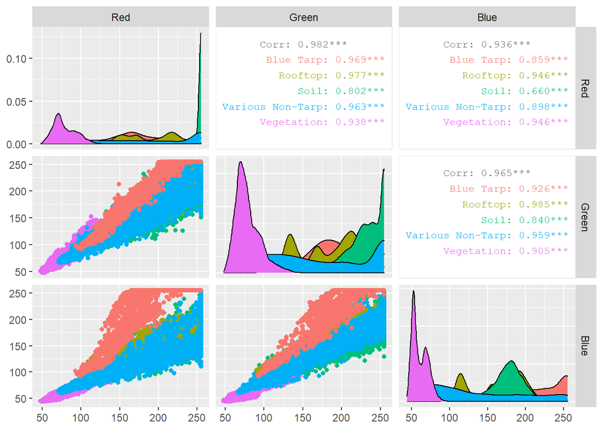

```r
#Reference [1]
# The palette with grey:
cbPalette <- c("#999999", "#E69F00", "#56B4E9", "#009E73", "#F0E442", "#0072B2", "#D55E00", "#CC79A7")
# To use for fills, add
#scale_fill_manual(values=cbPalette)

df$Class <- factor(df$Class) #make Class a factor variable.
ggpairs(df[,2:4], lower.panel = NULL, upper = list(continuous = wrap("cor", size = 3)), aes(color=df$Class))# + scale_fill_manual(values=cbPalette)
```

```r
#view scatter and correlations
attach(df) #attach df variables
```

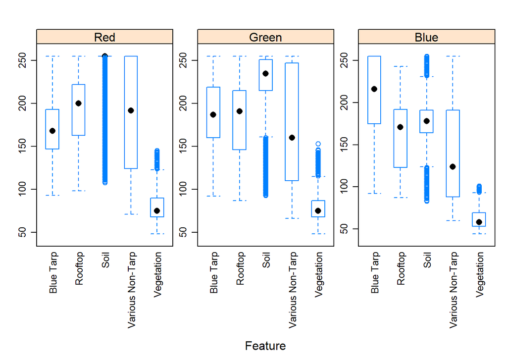

```r
#take a look at the distribution of classes and RBG values
featurePlot(x = df[,2:4],
            y = df$Class,
            plot = "box",
            layout = c(3,1),
            scales = list(y = list(relation = "free"),
                          x = list(rot = 90)))
```

## 3.2 Prepare Data Frame for Analysis

```r
df <- cbind(mutate(df, "Blue_Tarp_or_Not"=ifelse(Class != "Blue Tarp", 0, 1))) #add binary column indicating whether the Class variable is "Blue Tarp" or not
attach(df)
df$Blue_Tarp_or_Not <- factor(Blue_Tarp_or_Not) #ensure new column is a factor
head(df)
```

```
#>        Class Red Green Blue Blue_Tarp_or_Not
#> 1 Vegetation  64    67   50                0
#> 2 Vegetation  64    67   50                0
#> 3 Vegetation  64    66   49                0
#> 4 Vegetation  75    82   53                0
#> 5 Vegetation  74    82   54                0
#> 6 Vegetation  72    76   52                0
```

```r
df_factor <- df[, -1]
tail(df_factor)
```

```
#>       Red Green Blue Blue_Tarp_or_Not
#> 63236 136   145  150                1
#> 63237 138   146  150                1
#> 63238 134   141  152                1
#> 63239 136   143  151                1
#> 63240 132   139  149                1
#> 63241 133   141  153                1
```

## 3.3 Logistic Regression

```r
pass
```

```
#> Error in eval(expr, envir, enclos): object 'pass' not found
```

```r
fitControl <- trainControl(method = "cv",
                           number = 10,
                           returnResamp = 'all',
                           savePredictions = 'final',
                           classProbs = TRUE)

set.seed(4)
glm.fit <- caret::train(Blue_Tarp_or_Not~Red+Green+Blue,
                    data = df_factor,
                    method="glm",
                    family="binomial",
                    trControl= fitControl)
```

[output not shown]

```r
glm.fit
```

[output not shown]

[output cut: 183 more lines]

[output not shown]

```r
summary(glm.fit)
```

```
#> Error in object[[i]]: object of type 'closure' is not subsettable
```

```r
pass
```

```
#> Error in eval(expr, envir, enclos): object 'pass' not found
```

```r
glm.prob <- predict(glm.fit, newdata=df_factor, type = "prob") #returns df with col 0 (prob not blue tarp) and 1 (prob blue tarp)
```

```
#> Error in UseMethod("predict"): no applicable method for 'predict' applied to an object of class "function"
```

```r
par(pty="s")
glm_roc <- roc(df_factor$Blue_Tarp_or_Not, glm.prob[,2], plot=TRUE, legacy.axes=TRUE, percent=TRUE, xlab="False Positive Percentage", ylab="True Positive Percentage", col="#965fd4", lwd=4, print.auc=TRUE, main="GLM ROC Curve")
```

```
#> Error in roc.default(df_factor$Blue_Tarp_or_Not, glm.prob[, 2], plot = TRUE, : object 'glm.prob' not found
```

## 3.4 LDA

```r
pass
```

```
#> Error in eval(expr, envir, enclos): object 'pass' not found
```

```r
fitControl <- trainControl(method = "cv",
                           number = 10,
                           returnResamp = 'all',
                           savePredictions = 'final',
                           classProbs = TRUE)

set.seed(4)
lda.fit <- caret::train(Blue_Tarp_or_Not~Red+Green+Blue,
                    data = df_factor,
                    preProcess=c("center","scale"),
                    method="lda",
                    verbose= FALSE,
                    trControl= fitControl)
```

[output not shown]

```r
lda.fit
```

```
#> Error in eval(expr, envir, enclos): object 'lda.fit' not found
```

```r
#summary(lda.fit)
```

```r
pass
```

```
#> Error in eval(expr, envir, enclos): object 'pass' not found
```

```r
lda.prob <- predict(lda.fit, newdata=df_factor, type = "prob") #returns df with col 0 (prob not blue tarp) and 1 (prob blue tarp)
```

```
#> Error in predict(lda.fit, newdata = df_factor, type = "prob"): object 'lda.fit' not found
```

```r
par(pty="s")
lda_roc <- roc(df_factor$Blue_Tarp_or_Not, lda.prob[,2], plot=TRUE, legacy.axes=TRUE, percent=TRUE, xlab="False Positive Percentage", ylab="True Positive Percentage", col="#965fd4", lwd=4, print.auc=TRUE, main="LDA ROC Curve")
```

```
#> Error in roc.default(df_factor$Blue_Tarp_or_Not, lda.prob[, 2], plot = TRUE, : object 'lda.prob' not found
```

## 3.5 QDA

```r
pass
```

```
#> Error in eval(expr, envir, enclos): object 'pass' not found
```

```r
fitControl <- trainControl(method = "cv",
                           number = 10,
                           returnResamp = 'all',
                           savePredictions = 'final',
                           classProbs = TRUE)

set.seed(4)
qda.fit <- caret::train(Blue_Tarp_or_Not~Red+Green+Blue,
                    data = df_factor,
                    preProcess=c("center","scale"),
                    method="qda",
                    verbose= FALSE,
                    trControl= fitControl)
```

[output not shown]

```r
qda.fit
```

```
#> Error in eval(expr, envir, enclos): object 'qda.fit' not found
```

```r
pass
```

```
#> Error in eval(expr, envir, enclos): object 'pass' not found
```

```r
qda.prob <- predict(qda.fit, newdata=df_factor, type = "prob") #returns df with col 0 (prob not blue tarp) and 1 (prob blue tarp)
```

```
#> Error in predict(qda.fit, newdata = df_factor, type = "prob"): object 'qda.fit' not found
```

```r
par(pty="s")
qda_roc <- roc(df_factor$Blue_Tarp_or_Not, qda.prob[,2], plot=TRUE, legacy.axes=TRUE, percent=TRUE, xlab="False Positive Percentage", ylab="True Positive Percentage", col="#965fd4", lwd=4, print.auc=TRUE, main="QDA ROC Curve")
```

```
#> Error in roc.default(df_factor$Blue_Tarp_or_Not, qda.prob[, 2], plot = TRUE, : object 'qda.prob' not found
```

## 3.6 KNN

```r
pass
```

```
#> Error in eval(expr, envir, enclos): object 'pass' not found
```

```r
fitControl <- trainControl(method = "cv",
                           number = 10,
                           returnResamp = 'all',
                           savePredictions = 'final',
                           classProbs = TRUE)

set.seed(4)
knn.fit <- train(Blue_Tarp_or_Not~Red+Green+Blue,
                    data = df_factor,
                    preProcess=c("center","scale"),
                    method="knn",
                    trControl= fitControl,
                    tuneLength=5
                    )
```

[output not shown]

```r
knn.fit
```

```
#> Error in eval(expr, envir, enclos): object 'knn.fit' not found
```

```r
pass
```

```
#> Error in eval(expr, envir, enclos): object 'pass' not found
```

```r
knn.prob <- predict(knn.fit, newdata=df_factor, type = "prob") #returns df with col 0 (prob not blue tarp) and 1 (prob blue tarp)
```

```
#> Error in predict(knn.fit, newdata = df_factor, type = "prob"): object 'knn.fit' not found
```

```r
par(pty="s")
knn_roc <- roc(df_factor$Blue_Tarp_or_Not, knn.prob[,2], plot=TRUE, legacy.axes=TRUE, percent=TRUE, xlab="False Positive Percentage", ylab="True Positive Percentage", col="#965fd4", lwd=4, print.auc=TRUE, main="KNN ROC Curve")
```

```
#> Error in roc.default(df_factor$Blue_Tarp_or_Not, knn.prob[, 2], plot = TRUE, : object 'knn.prob' not found
```

## 3.7 Random Forest

```r
pass
```

```
#> Error in eval(expr, envir, enclos): object 'pass' not found
```

```r
fitControl <- trainControl(method = "cv",
                           number = 10,
                           returnResamp = 'all',
                           savePredictions = 'final',
                           classProbs = TRUE)

set.seed(4)
rf.fit <- train(Blue_Tarp_or_Not~Red+Green+Blue,
                    data = df_factor,
                    preProcess=c("center","scale"),
                    method="rf", #what is the difference between the different caret rf models??
                    trControl= fitControl,
                    tuneLength=3
                    )
```

[output not shown]

```r
rf.fit
```

```
#> Error in eval(expr, envir, enclos): object 'rf.fit' not found
```

## 3.8 SVM

```r
pass
```

```
#> Error in eval(expr, envir, enclos): object 'pass' not found
```

```r
fitControl <- trainControl(method = "cv",
                           number = 10,
                           returnResamp = 'all',
                           savePredictions = 'final',
                           classProbs = TRUE)

set.seed(4)
svm.radial.fit <- train(Blue_Tarp_or_Not~Red+Green+Blue,
                    data = df_factor,
                    preProcess=c("center","scale"),
                    method="svmRadial",
                    trControl= fitControl,
                    tuneLength=3
                    )
```

[output not shown]

```r
svm.radial.fit
```

```
#> Error in eval(expr, envir, enclos): object 'svm.radial.fit' not found
```

```r
pass
```

```
#> Error in eval(expr, envir, enclos): object 'pass' not found
```

```r
fitControl <- trainControl(method = "cv",
                           number = 10,
                           returnResamp = 'all',
                           savePredictions = 'final',
                           classProbs = TRUE)

set.seed(4)
svm.linear.fit <- train(Blue_Tarp_or_Not~Red+Green+Blue,
                    data = df_factor,
                    preProcess=c("center","scale"),
                    method="svmLinear",
                    trControl= fitControl,
                    tuneLength=3
                    )
```

[output not shown]

```r
svm.linear.fit
```

```
#> Error in eval(expr, envir, enclos): object 'svm.linear.fit' not found
```

```r
pass
```

```
#> Error in eval(expr, envir, enclos): object 'pass' not found
```

```r
fitControl <- trainControl(method = "cv",
                           number = 10,
                           returnResamp = 'all',
                           savePredictions = 'final',
                           classProbs = TRUE)

set.seed(4)
svm.poly.fit <- train(Blue_Tarp_or_Not~Red+Green+Blue,
                    data = df_factor,
                    preProcess=c("center","scale"),
                    method="svmPoly",
                    trControl= fitControl,
                    tuneLength=3
                    )
```

[output not shown]

```r
svm.poly.fit
```

```
#> Error in eval(expr, envir, enclos): object 'svm.poly.fit' not found
```

## 3.9 K-Folds Out of Sampling Performance

### 3.9.1 Table 2 - Performance Metrics: 10-Fold Cross-Validation Metrics

```r
acc_knn <- 300
```

[output not shown]

## 3.11 Hold-Out Test Sample Performance

### 3.11.1 Table 3 - Performance Metrics: Hold-Out Test Data Set Scores

[output not shown]

## 3.12 Future Work

```r
#consider if I was able to find an additional data source like lidar or infrared to pair with this dataset to improve model performance... ?
```

# 4 References and Works Cited

- [1] Creating and using color blindness friendly color pallets: http://www.cookbook-r.com/Graphs/Colors_(ggplot2)/#a-colorblind-friendly-palette
- Thanks to Derek Banks for sharing code for doing multicore processing
- Assigning color to ggplot scatter: https://www.r-graph-gallery.com/ggplot2-color.html
- Change correlation text size ggpairs : https://stackoverflow.com/questions/8599685/how-to-change-correlation-text-size-in-ggpairs
- Information on RGB color model: https://en.wikipedia.org/wiki/RGB_color_model
- Inspiration to color-code the ggpairs figure came from Professor Schwartz showing us another student’s project [Michael Davies] in class.

# 5 Appendix A: Analysis Methods Reference Info

[output not shown]